# Video Game Genre Classification

## 2. Data Analysis

The project will use the following models for data analysis:

-Random Forest -Gradient Boosted Tree -Neural Network

The rows will be randomized and the data will be split to training and testing, and the numeric attributes will be scaled.

```r
set.seed(1)
video_game <- video_game[sample(nrow(video_game), replace = FALSE),]
```

The data will be partitioned into 90% training and 10% testing data.

```r
library(caret)
set.seed(1)

game_index <- createDataPartition(video_game$genre, p = .90, list = FALSE)

game_train <- video_game[game_index, ]
game_test <- video_game[-game_index,]

##Duplicate the test/training data when variables need to be numeric
game_train_num <- game_train
game_test_num <- game_test
```

#SVM Linear

```r
set.seed(1)


linear_grid = expand.grid(C = c(.5, 1, 2, 5))

svm_linear <- train(genre~., data = game_train_num, method = "svmLinear", tuneGrid = linear_grid, trControl = trainControl("cv", number = 10))
```

```r
library(pROC)
svm_linear
```

```
Support Vector Machines with Linear Kernel

14698 samples
    9 predictor
   12 classes: 'Action', 'Adventure', 'Fighting', 'Misc', 'Platform', 'Puzzle', 'Racing', 'Role-Playing', 'Shooter', 'Simulation', 'Sports', 'Strategy'

No pre-processing
Resampling: Cross-Validated (10 fold)
Summary of sample sizes: 13228, 13227, 13228, 13228, 13228, 13227, ...
Resampling results across tuning parameters:

  C    Accuracy   Kappa
  0.5  0.2186022  0.06321037
  1.0  0.2240435  0.06916262
  2.0  0.2187376  0.06501843
  5.0  0.2254003  0.06585658

Accuracy was used to select the optimal model using the largest value.
The final value used for the model was C = 5.
```

```r
linear_pred <- predict(svm_linear, game_test_num)
linear_matrix <- confusionMatrix(linear_pred, game_test_num$genre)

linear_matrix
```

```
Confusion Matrix and Statistics

              Reference
Prediction     Action Adventure Fighting Misc Platform Puzzle Racing Role-Playing Shooter Simulation Sports Strategy
  Action          294       116       67  146       78     48     92          128     110         63    155       61
  Adventure         0         0        0    0        0      0      0            0       0          0      0        0
  Fighting          0         0        2    0        0      1      1            4       0          0      0        0
  Misc              0         0        0    1        0      0      0            0       0          0      1        0
  Platform          1         0        0    0        0      0      0            0       0          1      1        0
  Puzzle            1         0        0    0        0      2      0            1       0          0      0        0
  Racing            0         1        4    0        0      0      1            0       0          0      0        0
  Role-Playing      0         0        0    0        0      0      0            0       0          0      0        0
  Shooter           0         1        0    0        0      0      0            1       0          0      0        0
  Simulation        1         0        0    0        0      0      0            1       0          2      0        0
  Sports           28         8       10   24        9      6     27           12      18         19     73        6
  Strategy          0         1        0    0        0      0      1            0       0          0      0        0

Overall Statistics

               Accuracy : 0.2302
                 95% CI : (0.21, 0.2514)
    No Information Rate : 0.1995
    P-Value [Acc > NIR] : 0.001263

                  Kappa : 0.0517

 Mcnemar's Test P-Value : NA

Statistics by Class:

                     Class: Action Class: Adventure Class: Fighting Class: Misc Class: Platform Class: Puzzle Class: Racing Class: Role-Playing Class: Shooter Class: Simulation Class: Sports
Sensitivity                 0.9046          0.00000        0.024096   0.0058480        0.000000      0.035088     0.0081967             0.00000       0.000000          0.023529       0.31739
Specificity                 0.1840          1.00000        0.996119   0.9993141        0.998054      0.998728     0.9966821             1.00000       0.998668          0.998705       0.88063
Pos Pred Value              0.2165              NaN        0.250000   0.5000000        0.000000      0.500000     0.1666667                 NaN       0.000000          0.500000       0.30417
Neg Pred Value              0.8856          0.92204        0.950031   0.8955132        0.946494      0.966154     0.9254467             0.90976       0.921328          0.948923       0.88697
Prevalence                  0.1995          0.07796        0.050952   0.1049724        0.053407      0.034991     0.0748926             0.09024       0.078576          0.052179       0.14119
Detection Rate              0.1805          0.00000        0.001228   0.0006139        0.000000      0.001228     0.0006139             0.00000       0.000000          0.001228       0.04481
Detection Prevalence        0.8336          0.00000        0.004911   0.0012277        0.001842      0.002455     0.0036832             0.00000       0.001228          0.002455       0.14733
Balanced Accuracy           0.5443          0.50000        0.510108   0.5025810        0.499027      0.516908     0.5024394             0.50000       0.499334          0.511117       0.59901
                     Class: Strategy
Sensitivity                 0.000000
Specificity                 0.998720
Pos Pred Value              0.000000
Neg Pred Value              0.958820
Prevalence                  0.041130
Detection Rate              0.000000
Detection Prevalence        0.001228
Balanced Accuracy           0.499360
```

```r
linear_AUC <- multiclass.roc(as.numeric(game_test_num$genre), as.numeric(linear_pred))
linear_AUC
```

```
Call:
multiclass.roc.default(response = as.numeric(game_test_num$genre),     predictor = as.numeric(linear_pred))

Data: as.numeric(linear_pred) with 12 levels of as.numeric(game_test_num$genre): 1, 2, 3, 4, 5, 6, 7, 8, 9, 10, 11, 12.
Multi-class area under the curve: 0.5213
```

#SVM Radial

```r
set.seed(1)

svm_radial <- train(genre ~., data = game_train_num, trControl = trainControl(method = "cv", number = 10), method = "svmRadial")
```

```r
svm_radial
```

```
Support Vector Machines with Radial Basis Function Kernel

14698 samples
    9 predictor
   12 classes: 'Action', 'Adventure', 'Fighting', 'Misc', 'Platform', 'Puzzle', 'Racing', 'Role-Playing', 'Shooter', 'Simulation', 'Sports', 'Strategy'

No pre-processing
Resampling: Cross-Validated (10 fold)
Summary of sample sizes: 13228, 13227, 13228, 13228, 13228, 13227, ...
Resampling results across tuning parameters:

  C     Accuracy   Kappa
  0.25  0.2033614  0.02068584
  0.50  0.2034976  0.02136922
  1.00  0.2037017  0.02169948

Tuning parameter 'sigma' was held constant at a value of 6.091264e-07
Accuracy was used to select the optimal model using the largest value.
The final values used for the model were sigma = 6.091264e-07 and C = 1.
```

```r
radial_pred <- predict(svm_radial, game_test_num)

radial_matrix <- confusionMatrix(radial_pred, game_test_num$genre)

radial_matrix
```

```
Confusion Matrix and Statistics

              Reference
Prediction     Action Adventure Fighting Misc Platform Puzzle Racing Role-Playing Shooter Simulation Sports Strategy
  Action          286        94       79  158       83     48    114          134     119         76    218       57
  Adventure        39        33        4   13        4      9      8           13       9          9     12       10
  Fighting          0         0        0    0        0      0      0            0       0          0      0        0
  Misc              0         0        0    0        0      0      0            0       0          0      0        0
  Platform          0         0        0    0        0      0      0            0       0          0      0        0
  Puzzle            0         0        0    0        0      0      0            0       0          0      0        0
  Racing            0         0        0    0        0      0      0            0       0          0      0        0
  Role-Playing      0         0        0    0        0      0      0            0       0          0      0        0
  Shooter           0         0        0    0        0      0      0            0       0          0      0        0
  Simulation        0         0        0    0        0      0      0            0       0          0      0        0
  Sports            0         0        0    0        0      0      0            0       0          0      0        0
  Strategy          0         0        0    0        0      0      0            0       0          0      0        0

Overall Statistics

               Accuracy : 0.1958
                 95% CI : (0.1768, 0.2159)
    No Information Rate : 0.1995
    P-Value [Acc > NIR] : 0.6546

                  Kappa : 0.0104

 Mcnemar's Test P-Value : NA

Statistics by Class:

                     Class: Action Class: Adventure Class: Fighting Class: Misc Class: Platform Class: Puzzle Class: Racing
Sensitivity                0.88000          0.25984         0.00000       0.000         0.00000       0.00000       0.00000
Specificity                0.09509          0.91345         1.00000       1.000         1.00000       1.00000       1.00000
Pos Pred Value             0.19509          0.20245             NaN         NaN             NaN           NaN           NaN
Neg Pred Value             0.76074          0.93588         0.94905       0.895         0.94659       0.96501       0.92511
Prevalence                 0.19951          0.07796         0.05095       0.105         0.05341       0.03499       0.07489
Detection Rate             0.17557          0.02026         0.00000       0.000         0.00000       0.00000       0.00000
Detection Prevalence       0.89994          0.10006         0.00000       0.000         0.00000       0.00000       0.00000
Balanced Accuracy          0.48755          0.58665         0.50000       0.500         0.50000       0.50000       0.50000
                     Class: Role-Playing Class: Shooter Class: Simulation Class: Sports Class: Strategy
Sensitivity                      0.00000        0.00000           0.00000        0.0000         0.00000
Specificity                      1.00000        1.00000           1.00000        1.0000         1.00000
Pos Pred Value                       NaN            NaN               NaN           NaN             NaN
Neg Pred Value                   0.90976        0.92142           0.94782        0.8588         0.95887
Prevalence                       0.09024        0.07858           0.05218        0.1412         0.04113
Detection Rate                   0.00000        0.00000           0.00000        0.0000         0.00000
Detection Prevalence             0.00000        0.00000           0.00000        0.0000         0.00000
Balanced Accuracy                0.50000        0.50000           0.50000        0.5000         0.50000
```

```r
radial_AUC <- multiclass.roc(as.numeric(game_test_num$genre), as.numeric(radial_pred))
radial_AUC
```

```
Call:
multiclass.roc.default(response = as.numeric(game_test_num$genre),     predictor = as.numeric(radial_pred))

Data: as.numeric(radial_pred) with 12 levels of as.numeric(game_test_num$genre): 1, 2, 3, 4, 5, 6, 7, 8, 9, 10, 11, 12.
Multi-class area under the curve: 0.4914
```

#Random Forest

Here we will train a random forest model.

```r
library(randomForest)
library(caret)
set.seed(1)

ctrl <- trainControl(method = "cv", number = 10)
grid_rf <- expand.grid(mtry = c(1, 3, 10))


m_rf <- train(genre ~ ., data = game_train, method = "rf", trControl = ctrl, metric = "Kappa", tuneGrid = grid_rf, importance = TRUE, proximity = TRUE)
```

Predictions were generated and compared with the model and the test data. A confusion matrix of the predictions and the outcome variable in the test data was made. Finally, AUC was calculated using the multiclass.roc function from the pROC package.

```r
library(caret)
library(pROC)
m_rf
```

```
Random Forest

14698 samples
    9 predictor
   12 classes: 'Action', 'Adventure', 'Fighting', 'Misc', 'Platform', 'Puzzle', 'Racing', 'Role-Playing', 'Shooter', 'Simulation', 'Sports', 'Strategy'

No pre-processing
Resampling: Cross-Validated (10 fold)
Summary of sample sizes: 13228, 13227, 13228, 13228, 13228, 13227, ...
Resampling results across tuning parameters:

  mtry  Accuracy   Kappa
   1    0.1992108  0.0000000
   3    0.1992108  0.0000000
  10    0.2894953  0.1472838

Kappa was used to select the optimal model using the largest value.
The final value used for the model was mtry = 10.
```

```r
varImp(m_rf)
```

```
rf variable importance

  variables are sorted by maximum importance across the classes
  only 20 most important variables shown (out of 615)
```

|  | Action | Adventure | Fighting | Misc | Platform | Puzzle | Racing | Role-Playing | Shooter | Simulation | Sports | Strategy |
| --- | --- | --- | --- | --- | --- | --- | --- | --- | --- | --- | --- | --- |
| publisherElectronic Arts | 22.708129 | 72.799822 | 53.16565 | 68.980486 | 53.93220 | 46.89919 | 37.61483 | 70.454138 | 24.38202 | 43.09176 | 100.00000 | 28.30422 |
| publisherCodemasters | 62.175793 | 52.714707 | 38.59331 | 40.661089 | 33.85501 | 33.78010 | 94.55349 | 50.896474 | 32.81138 | 36.44397 | 45.94228 | 14.04731 |
| na_sales | 70.157238 | 93.238614 | 33.49450 | 9.261717 | 53.34271 | 31.13216 | 36.35462 | 27.097261 | 26.40861 | 35.37219 | 51.98776 | 65.09726 |
| publisherKonami Digital Entertainment | 29.910356 | 44.337132 | 45.44935 | 34.094949 | 31.45080 | 33.63459 | 49.19055 | 57.207187 | 35.88795 | 47.97673 | 92.40080 | 52.55443 |
| year | 89.116339 | 24.452716 | 42.56214 | 65.708782 | 54.12531 | 38.09010 | 53.76105 | 2.010511 | 46.10923 | 48.79122 | 75.61218 | 37.05631 |
| publisherMTV Games | 62.346895 | 36.173442 | 29.48864 | 87.310038 | 31.51061 | 28.05671 | 33.78049 | 36.399772 | 33.08864 | 31.52249 | 54.17053 | 30.59045 |
| eu_sales | 74.477312 | 86.369419 | 37.74192 | 47.393593 | 47.88118 | 24.74421 | 43.40594 | 59.870090 | 45.84415 | 45.13650 | 28.54588 | 41.88596 |
| jp_sales | 43.423586 | 82.183993 | 43.99113 | 46.787225 | 46.17068 | 48.41954 | 59.75590 | 85.812116 | 31.91318 | 48.36645 | 74.21187 | 52.39235 |
| publisherSquare Enix | 0.000000 | 51.108432 | 40.52877 | 45.208404 | 41.23448 | 21.50185 | 41.25542 | 85.705049 | 21.57766 | 32.45434 | 67.73885 | 28.14657 |
| platformPC | 22.354477 | 48.169626 | 50.80169 | 59.793683 | 50.01729 | 26.38080 | 17.51470 | 55.910259 | 48.51831 | 42.89544 | 68.23466 | 83.87582 |

[output cut: 10 more lines]

```r
predictions <- predict(m_rf, game_test_num)
predictions_prob = predict(m_rf, game_test_num, type = "prob")



conf_matrix <- confusionMatrix(predictions, game_test_num$genre)

conf_matrix
```

```
Confusion Matrix and Statistics

              Reference
Prediction     Action Adventure Fighting Misc Platform Puzzle Racing Role-Playing Shooter Simulation Sports Strategy
  Action          259        63       50   81       68     27     74           87      92         40    104       33
  Adventure        15        31        8   22        1      2      1           10       7          8      5        6
  Fighting          0         0        1    0        0      0      0            0       0          0      0        0
  Misc              5         8        1   27        2      9      3            4       4          8      5        3
  Platform          0         0        0    0        1      1      0            0       0          0      0        0
  Puzzle            0         0        0    0        0      0      0            0       0          0      0        0
  Racing            0         0        0    0        0      0      4            0       1          0      0        0
  Role-Playing      9         7        6    8        2      5      2           31       2          3      8        8
  Shooter           0         0        0    0        0      0      0            0       0          0      0        0
  Simulation        0         0        0    0        0      0      0            0       0          0      0        0
  Sports           34        15       17   32       12      9     37           11      20         23    106       12
  Strategy          3         3        0    1        1      4      1            4       2          3      2        5

Overall Statistics

               Accuracy : 0.2855
                 95% CI : (0.2636, 0.3081)
    No Information Rate : 0.1995
    P-Value [Acc > NIR] : < 2.2e-16

                  Kappa : 0.1443

 Mcnemar's Test P-Value : NA

Statistics by Class:

                     Class: Action Class: Adventure Class: Fighting Class: Misc Class: Platform Class: Puzzle Class: Racing
Sensitivity                 0.7969          0.24409       0.0120482     0.15789       0.0114943       0.00000      0.032787
Specificity                 0.4486          0.94341       1.0000000     0.96433       0.9993515       1.00000      0.999336
Pos Pred Value              0.2648          0.26724       1.0000000     0.34177       0.5000000           NaN      0.800000
Neg Pred Value              0.8986          0.93655       0.9496314     0.90710       0.9471420       0.96501      0.927340
Prevalence                  0.1995          0.07796       0.0509515     0.10497       0.0534070       0.03499      0.074893
Detection Rate              0.1590          0.01903       0.0006139     0.01657       0.0006139       0.00000      0.002455
Detection Prevalence        0.6004          0.07121       0.0006139     0.04850       0.0012277       0.00000      0.003069
Balanced Accuracy           0.6228          0.59375       0.5060241     0.56111       0.5054229       0.50000      0.516062
                     Class: Role-Playing Class: Shooter Class: Simulation Class: Sports Class: Strategy
Sensitivity                      0.21088        0.00000           0.00000       0.46087        0.074627
Specificity                      0.95951        1.00000           1.00000       0.84132        0.984635
Pos Pred Value                   0.34066            NaN               NaN       0.32317        0.172414
Neg Pred Value                   0.92458        0.92142           0.94782       0.90469        0.961250
Prevalence                       0.09024        0.07858           0.05218       0.14119        0.041130
Detection Rate                   0.01903        0.00000           0.00000       0.06507        0.003069
Detection Prevalence             0.05586        0.00000           0.00000       0.20135        0.017802
Balanced Accuracy                0.58520        0.50000           0.50000       0.65109        0.529631
```

```r
rf_AUC <- multiclass.roc(as.numeric(game_test_num$genre), as.numeric(predictions))
rf_AUC
```

```
Call:
multiclass.roc.default(response = as.numeric(game_test_num$genre),     predictor = as.numeric(predictions))

Data: as.numeric(predictions) with 12 levels of as.numeric(game_test_num$genre): 1, 2, 3, 4, 5, 6, 7, 8, 9, 10, 11, 12.
Multi-class area under the curve: 0.5673
```

Random forest rankings are shown using varImp function.

#Gradient Boosted Tree Model

```r
set.seed(1)

gbm <- train(genre ~., data =game_train, method ="gbm", trControl = trainControl("cv", number= 10))
```

```r
gbm
```

```
Stochastic Gradient Boosting

14698 samples
    9 predictor
   12 classes: 'Action', 'Adventure', 'Fighting', 'Misc', 'Platform', 'Puzzle', 'Racing', 'Role-Playing', 'Shooter', 'Simulation', 'Sports', 'Strategy'

No pre-processing
Resampling: Cross-Validated (10 fold)
Summary of sample sizes: 13228, 13227, 13228, 13228, 13228, 13227, ...
Resampling results across tuning parameters:

  interaction.depth  n.trees  Accuracy   Kappa
  1                   50      0.3069811  0.1835476
  1                  100      0.3228333  0.2099505
  1                  150      0.3283446  0.2203879
  2                   50      0.3282072  0.2158105
  2                  100      0.3447396  0.2421510
  2                  150      0.3517490  0.2530781
  3                   50      0.3418832  0.2360986
  3                  100      0.3539923  0.2558001
  3                  150      0.3624293  0.2679067

Tuning parameter 'shrinkage' was held constant at a value of 0.1
Tuning parameter 'n.minobsinnode' was held constant at a value of 10
Accuracy was used to select the optimal model using the largest value.
The final values used for the model were n.trees = 150, interaction.depth = 3, shrinkage = 0.1 and n.minobsinnode = 10.
```

```r
gbm_predictions <- predict(gbm, game_test)
gbm_conf_matrix <- confusionMatrix(gbm_predictions, game_test$genre)

gbm_conf_matrix
```

```
Confusion Matrix and Statistics

              Reference
Prediction     Action Adventure Fighting Misc Platform Puzzle Racing Role-Playing Shooter Simulation Sports Strategy
  Action          187        28       26   45       39     13     36           42      51         22     39       13
  Adventure        13        40        4   20        0      2      2            4       5          7      4        4
  Fighting          9         2       22    5        1      2      3            1       5          2      4        2
  Misc             22        18        3   46       14      7      8           11       7          8      8        6
  Platform          7         1        3    1       13      2      6            4       2          0      1        1
  Puzzle            2         2        0    3        0      8      1            0       1          1      2        1
  Racing            6         5        0    2        1      7     21            0       5          3      8        0
  Role-Playing     14         7        5   11        1      4      4           64       2          2      6        6
  Shooter          18         5        3    2        2      2      1            1      20          2      6        4
  Simulation       10         2        0    8        0      2      2            3       2         19      5        6
  Sports           34        14       17   26       15      4     36           11      26         15    140       10
  Strategy          3         3        0    2        1      4      2            6       2          4      7       14

Overall Statistics

               Accuracy : 0.3646
                 95% CI : (0.3412, 0.3885)
    No Information Rate : 0.1995
    P-Value [Acc > NIR] : < 2.2e-16

                  Kappa : 0.2687

 Mcnemar's Test P-Value : NA

Statistics by Class:

                     Class: Action Class: Adventure Class: Fighting Class: Misc Class: Platform Class: Puzzle Class: Racing
Sensitivity                 0.5754          0.31496         0.26506     0.26901         0.14943      0.140351       0.17213
Specificity                 0.7285          0.95672         0.97671     0.92318         0.98184      0.991730       0.97545
Pos Pred Value              0.3457          0.38095         0.37931     0.29114         0.31707      0.380952       0.36207
Neg Pred Value              0.8732          0.94291         0.96117     0.91502         0.95340      0.969527       0.93571
Prevalence                  0.1995          0.07796         0.05095     0.10497         0.05341      0.034991       0.07489
Detection Rate              0.1148          0.02455         0.01351     0.02824         0.00798      0.004911       0.01289
Detection Prevalence        0.3321          0.06446         0.03560     0.09699         0.02517      0.012891       0.03560
Balanced Accuracy           0.6520          0.63584         0.62089     0.59609         0.56563      0.566041       0.57379
                     Class: Role-Playing Class: Shooter Class: Simulation Class: Sports Class: Strategy
Sensitivity                      0.43537        0.15625           0.22353       0.60870        0.208955
Specificity                      0.95816        0.96935           0.97409       0.85132        0.978233
Pos Pred Value                   0.50794        0.30303           0.32203       0.40230        0.291667
Neg Pred Value                   0.94478        0.93090           0.95796       0.92974        0.966477
Prevalence                       0.09024        0.07858           0.05218       0.14119        0.041130
Detection Rate                   0.03929        0.01228           0.01166       0.08594        0.008594
Detection Prevalence             0.07735        0.04052           0.03622       0.21363        0.029466
Balanced Accuracy                0.69677        0.56280           0.59881       0.73001        0.593594
```

```r
gbm_AUC <- multiclass.roc(as.numeric(game_test_num$genre), as.numeric(gbm_predictions))
gbm_AUC
```

```
Call:
multiclass.roc.default(response = as.numeric(game_test_num$genre),     predictor = as.numeric(gbm_predictions))

Data: as.numeric(gbm_predictions) with 12 levels of as.numeric(game_test_num$genre): 1, 2, 3, 4, 5, 6, 7, 8, 9, 10, 11, 12.
Multi-class area under the curve: 0.6018
```

#Neural Network

Categorical variables besides the outcome variable (genre) will be converted to numeric.

```r
#Convert publisher and platform variable to indices
game_train_num$publisher = sapply(game_train_num$publisher, as.numeric)
game_train_num$platform = sapply(game_train_num$platform, as.numeric)

game_test_num$publisher = sapply(game_test_num$publisher, as.numeric)
game_test_num$platform = sapply(game_test_num$platform, as.numeric)
```

Numerical variables will need to be scaled.

```r
numeric_cols = c("rank", "year", "na_sales", "eu_sales", "jp_sales", "other_sales","global_sales")

col_means_train <- attr(scale(game_train_num[,numeric_cols]), "scaled:center")
col_stddevs_train <- attr(scale(game_train_num[,numeric_cols]), "scaled:scale")


game_train_num[numeric_cols] = scale(game_train_num[numeric_cols])
game_test_num[numeric_cols] = scale(game_test_num[numeric_cols], center = col_means_train, scale = col_stddevs_train)
```

```r
library(keras)
```

The training data will be split again to form the validation data that will be used for hyper-parameter tuning. Platform will be one-hot encoded using the to_categorical function from the kerasR package.

```r
set.seed(1)
in_train <- createDataPartition(game_train_num$genre, p = 0.8, list = FALSE)

game_train_nn <- as.data.frame(game_train_num[in_train, -4])
game_validation_nn <- as.data.frame(game_train_num[-in_train, -4])

game_train_nn_labels = to_categorical(as.numeric(game_train_num[in_train, 4]))
game_validation_nn_labels <- to_categorical(as.numeric(game_train_num[-in_train, 4]))

game_test_nn_labels <- game_test_num$genre

game_train_nn_labels <- game_train_nn_labels[, -1]
game_validation_nn_labels <- game_validation_nn_labels[, -1]


game_train_nn$publisher <- to_categorical(game_train_nn$publisher)
game_train_nn$platform <- to_categorical(game_train_nn$platform)
game_validation_nn$publisher <- to_categorical(game_validation_nn$publisher)
game_validation_nn$platform <- to_categorical(game_validation_nn$platform)
game_test_num$publisher <- to_categorical(game_test_num$publisher)
game_test_num$platform <- to_categorical(game_test_num$platform)
```

```r
game_train_nn$publisher <- game_train_nn$publisher[, -1]
game_train_nn$platform <- game_train_nn$platform[, -1]

game_validation_nn$publisher <- game_validation_nn$publisher[, -1]
game_validation_nn$platform <- game_validation_nn$platform[, -1]

game_test_num$publisher <- game_test_num$publisher[, -1]
game_test_num$platform <- game_test_num$platform[, -1]
```

```r
library(data.table)
game_train_nn_dt <- as.data.table(game_train_nn)
game_validation_nn_dt <- as.data.table(game_validation_nn)
```

```r
model = keras_model_sequential()
```

```
2023-05-07 18:36:19.842585: I tensorflow/core/platform/cpu_feature_guard.cc:193] This TensorFlow binary is optimized with oneAPI Deep Neural Network Library (oneDNN) to use the following CPU instructions in performance-critical operations:  AVX AVX2
To enable them in other operations, rebuild TensorFlow with the appropriate compiler flags.
```

```r
model %>%
  layer_dense(units = 60, activation = "relu", input_shape = 617) %>%
  layer_dense(units = 25, activation = "relu") %>%
  layer_dense(units = 12, activation = "softmax")

set.seed(1)

model %>% compile(
  loss = "categorical_crossentropy",
  optimizer = "adam",
  metrics = "accuracy"
)


history = model %>% fit(
  as.matrix(game_train_nn_dt), game_train_nn_labels,
  epochs = 50,
  batch_size = 100,
  validation_data = list(as.matrix(game_validation_nn_dt), game_validation_nn_labels)
)
```

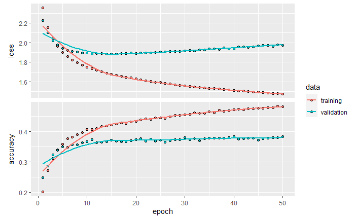

```r
plot(history)
```

We will use the “tfruns” package to adjust the hyper parameters. We will add dropout layers in the Project_Flag.R script to regularize the neural network.

```r
library(tfruns)
runs <- tuning_run("Project_Flag.R",
                   flags = list(
                     nodes = c(60, 128, 490),
                     batch_size = c(100, 200, 500, 1000),
                     activation = c("relu", "softmax")
                   ),
                   sample = 0.1

)
```

```
24 total combinations of flags
(sampled to 3 combinations)
```

```r
Y
```

```
Training run 1/3 (flags = list(60, 200, "relu"))
Using run directory runs/2023-05-07T23-36-49Z
```

[output not shown]

```
WARNING:tensorflow:Callback method `on_train_batch_end` is slow compared to the batch time (batch time: 0.0022s vs `on_train_batch_end` time: 0.0037s). Check your callbacks.
```

```
Run completed: runs/2023-05-07T23-36-49Z

Training run 2/3 (flags = list(60, 500, "relu"))
Using run directory runs/2023-05-07T23-37-27Z
```

[output not shown]

```
WARNING:tensorflow:Callback method `on_train_batch_end` is slow compared to the batch time (batch time: 0.0022s vs `on_train_batch_end` time: 0.0027s). Check your callbacks.
```

```
Run completed: runs/2023-05-07T23-37-27Z

Training run 3/3 (flags = list(60, 100, "relu"))
Using run directory runs/2023-05-07T23-37-57Z
```

[output not shown]

```
WARNING:tensorflow:Callback method `on_train_batch_end` is slow compared to the batch time (batch time: 0.0012s vs `on_train_batch_end` time: 0.0028s). Check your callbacks.
```

```
Run completed: runs/2023-05-07T23-37-57Z
```

```r
runs
```

```
Data frame: 3 x 25
```

|  | run_dir | metric_loss | metric_accuracy | metric_val_loss | metric_val_accuracy |
| --- | --- | --- | --- | --- | --- |
| 1 | runs/2023-05-07T23-37-57Z | 1.8000 | 0.3893 | 1.9138 | 0.3729 |
| 2 | runs/2023-05-07T23-37-27Z | 1.8380 | 0.3754 | 1.8851 | 0.3739 |
| 3 | runs/2023-05-07T23-36-49Z | 1.7991 | 0.3832 | 1.9111 | 0.3743 |

```
# ... with 20 more columns:
#   flag_nodes, flag_batch_size, flag_activation, flag_dropout1, flag_dropout2, epochs, epochs_completed, metrics, model,
#   loss_function, optimizer, learning_rate, script, start, end, completed, output, source_code, context, type
```

From the runs, number 1 had the highest accuracy and will be noted as the best model.

```r
view_run(runs$run_dir[1])
```

Parameters for model 1 are 60 nodes, batch_size of 100, relu activation, and dropout levels of 0.5 with 100 epochs.

We will now combine the validation data with the training.

```r
game_combined_matrix = rbind(game_train_nn_dt, game_validation_nn_dt)
game_labels_combined = rbind(game_train_nn_labels, game_validation_nn_labels)
```

We will now run this model again.

```r
model = keras_model_sequential()


model %>%
  layer_dense(units = 60, activation = "relu", input_shape = 617) %>%
  layer_dropout(0.5) %>%
  layer_dense(units = 60, activation = "relu") %>%
  layer_dropout(0.5) %>%
  layer_dense(units = 12, activation = "softmax")

set.seed(1)

model %>% compile(
  loss = "categorical_crossentropy",
  optimizer = "adam",
  metrics = "accuracy"
)

history = model %>% fit(
  as.matrix(game_combined_matrix), game_labels_combined,
  epochs = 100,
  batch_size = 100,
  validation_data = list(as.matrix(game_validation_nn_dt), game_validation_nn_labels)
)
```

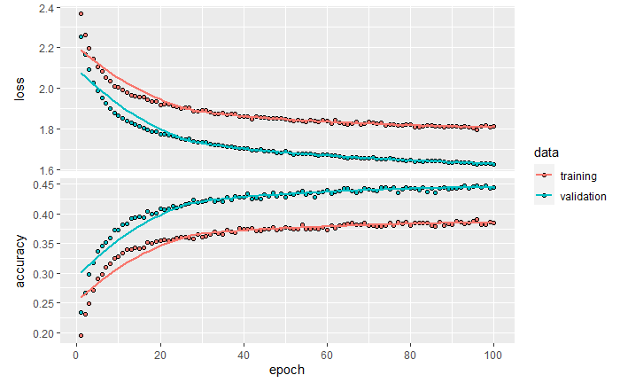

```r
plot(history)
```

Using this model, we will predict the genre for the test data.

```r
set.seed(1)


game_test_num_matrix <- as.matrix(game_test_num[,-4])

game_test_labels <- as.numeric(game_test_num$genre)



nn_pred <- model %>% predict(game_test_num_matrix)
nn_pred <- apply(nn_pred, 1, which.max)


nn_matrix <- confusionMatrix(as.factor(nn_pred), as.factor(game_test_labels))

nn_matrix
```

```
Confusion Matrix and Statistics

          Reference
Prediction   1   2   3   4   5   6   7   8   9  10  11  12
        1  209  34  35  49  48   8  37  35  67  24  43  20
        2    9  36   5   8   1   2   0   2   2   3   2   2
        3    6   1  15   1   0   1   2   0   1   1   1   1
        4   13  12   3  53  10   9   4   9   6   9   7   3
        5    3   0   2   1   8   4   3   4   0   2   3   2
        6    3   8   0   4   1   8   2   1   0   2   1   1
        7    2   3   0   3   4   7  19   2   3   2   3   1
        8   18   6   6   7   1   1   2  68   1   3   3   5
        9    5   3   1   2   0   1   0   2  13   1   1   4
        10   9   1   0   5   1   2   2   0   2  13   1   6
        11  47  18  16  37  12  12  49  18  33  20 164  12
        12   1   5   0   1   1   2   2   6   0   5   1  10

Overall Statistics

               Accuracy : 0.3781
                 95% CI : (0.3545, 0.4022)
    No Information Rate : 0.1995
    P-Value [Acc > NIR] : < 2.2e-16

                  Kappa : 0.2767

 Mcnemar's Test P-Value : NA

Statistics by Class:

                     Class: 1 Class: 2 Class: 3 Class: 4 Class: 5 Class: 6 Class: 7 Class: 8 Class: 9 Class: 10 Class: 11 Class: 12
Sensitivity            0.6431  0.28346 0.180723  0.30994 0.091954 0.140351  0.15574  0.46259  0.10156   0.15294    0.7130  0.149254
Specificity            0.6933  0.97603 0.990298  0.94170 0.984436 0.985369  0.98009  0.96424  0.98668   0.98122    0.8041  0.984635
Pos Pred Value         0.3432  0.50000 0.500000  0.38406 0.250000 0.258065  0.38776  0.56198  0.39394   0.30952    0.3744  0.294118
Neg Pred Value         0.8863  0.94155 0.957473  0.92086 0.950532 0.969337  0.93481  0.94761  0.92794   0.95463    0.9446  0.964263
Prevalence             0.1995  0.07796 0.050952  0.10497 0.053407 0.034991  0.07489  0.09024  0.07858   0.05218    0.1412  0.041130
Detection Rate         0.1283  0.02210 0.009208  0.03254 0.004911 0.004911  0.01166  0.04174  0.00798   0.00798    0.1007  0.006139
Detection Prevalence   0.3738  0.04420 0.018416  0.08471 0.019644 0.019030  0.03008  0.07428  0.02026   0.02578    0.2689  0.020872
Balanced Accuracy      0.6682  0.62975 0.585510  0.62582 0.538195 0.562860  0.56792  0.71341  0.54412   0.56708    0.7586  0.566944
```

```r
nn_AUC <- multiclass.roc(as.numeric(nn_pred), as.numeric(game_test_labels))
nn_AUC
```

```
Call:
multiclass.roc.default(response = as.numeric(nn_pred), predictor = as.numeric(game_test_labels))

Data: as.numeric(game_test_labels) with 12 levels of as.numeric(nn_pred): 1, 2, 3, 4, 5, 6, 7, 8, 9, 10, 11, 12.
Multi-class area under the curve: 0.6379
```